# Mv_Lab_2

Kim Youngrae

2016년 10월 10일

# Content

- 연습문제 5.9
- 연습문제 5.16
- 연습문제 5.17
- 예제 6.10
- 예제 6.11

# 연습문제 5.9

```r
data<-read.csv("/users/kyr0302/Desktop/lab_2/P5-9.dat",header=FALSE,sep="");
xbar<-c(95.92,164.38,55.69,93.39,17.98,31.13);
cov<-matrix(rep(0,6*6),nrow=6)
cov<-data[1:6,];cov[6,6]<-21.26;
cov[upper.tri(cov,diag=F)]=0
cov<-cov+t(cov)-diag(c(3266.46,721.91,179.28,474.98,9.95,21.26))
```

교재에 있는 연습문제 5.9를 풀어보도록 한다. 교재의 자료를 입력하면 다음과 같다.

```r
xbar;cov;
```

```
## [1]  95.92 164.38  55.69  93.39  17.98  31.13
```

```
##        V1      V2     V3      V4     V5     V6
## 1 3266.46 1343.97 731.54 1175.50 162.68 238.37
## 2 1343.97  721.91 324.25  537.35  80.17 117.73
## 3  731.54  324.25 179.28  281.17  39.15  56.80
## 4 1175.50  537.35 281.17  474.98  63.73  94.85
## 5  162.68   80.17  39.15   63.73   9.95  13.88
## 6  238.37  117.73  56.80   94.85  13.88  21.26
```

#### (a) Obtain the large sample 95% simultaneous confidence intervals for the six population mean body measurements.

$x_1$에 대한 신뢰구간은 다음과 같이 구할수 있다. $(\bar{x}_1-\sqrt{\frac{p(n-1)}{n(n-p)}F_{p,n-p}(\alpha)}\sqrt{\frac{s_{11}}{n}},\bar{x}_1+\sqrt{\frac{p(n-1)}{n(n-p)}F_{p,n-p}(\alpha)}\sqrt{\frac{s_{11}}{n}})$

Large sample인 경우, $(\bar{x}_1-\sqrt{\chi_p^2(\alpha)}\sqrt{\frac{s_{11}}{n}},\bar{x}_1+\sqrt{\chi_p^2(\alpha)}\sqrt{\frac{s_{11}}{n}})$ 로 구할 수 있다.

이를 이용해서 여섯개의 변수에 대해 각각 신뢰구간을 구하면 다음과 같다.

```r
n=61; p=6; lb<-rep(0,p); ub<-rep(0,p);
for(i in 1:p){
  a<-sqrt(qchisq(0.95,p)*cov[i,i]/n);
  lb[i]<-xbar[i]-a; ub[i]<-xbar[i]+a
}
ci<-cbind(lb,ub)
ci
```

```
##             lb        ub
## [1,]  69.95347 121.88653
## [2,] 152.17278 176.58722
## [3,]  49.60667  61.77333
## [4,]  83.48823 103.29177
## [5,]  16.54687  19.41313
## [6,]  29.03513  33.22487
```

#### (b) Obtain the large sample 95% simultaneous confidence ellipse for mean weight and mean girth.

이를 만족하는 ellipse를 그리면 된다.

R의 car library안에 ellipse라는 함수를 이용한다.

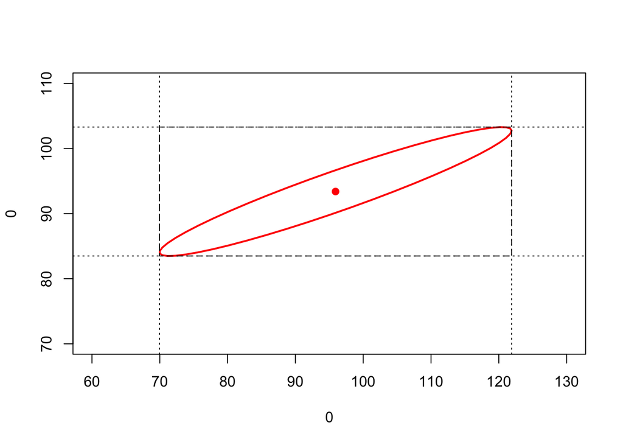

```r
partxbar<-xbar[c(1,4)]; partcov<-cov[c(1,4),c(1,4)]
library(car)
plot(0,0,xlim=c(60,130),ylim=c(70,110))
ellipse(partxbar, as.matrix(partcov), sqrt(qchisq(0.95,p)/n), center.pch=19,         center.cex=1,
        segments=51, add=TRUE, xlab="", ylab="",
        las=par('las'), col=palette()[2], lwd=2, lty=1)
rect(ci[1,1],ci[4,1],ci[1,2],ci[4,2],lty=2)
abline(v=ci[1,1],lty=3); abline(v=ci[1,2],lty=3);
abline(h=ci[4,1],lty=3); abline(h=ci[4,2],lty=3);
```

위와 같이 그려지며, 타원을 축에 사영시키면, (a)에서 구한 신뢰구간이 나오는 것을 확인할 수 있다.

#### (c) Obtain the 95% Bonferroni confidence intervals for the six menas in Part a.

Bonferroni confidence interval은 다음과 같다. 총 p개의 변수가 있을 때, 각 변수의 신뢰구간을 구하면, $(\bar{x}_i - t_{n-1}(\frac{\alpha}{2p})\sqrt{\frac{s_{ii}}{n}},\bar{x}_i+t_{n-1}(\frac{\alpha}{2p})\sqrt{\frac{s_{ii}}{n}})$

Large sample인 경우엔 t를 z로 바꿀수 있으므로, $(\bar{x}_i - z(\frac{\alpha}{2p})\sqrt{\frac{s_{ii}}{n}},\bar{x}_i+z(\frac{\alpha}{2p})\sqrt{\frac{s_{ii}}{n}})$

이를 바탕으로 본페로니 신뢰구간을 계산하면 다음과 같다.

```r
bflb<-rep(0,p); bfub<-rep(0,p);
for(i in 1:p){
  a<-qnorm(0.05/(2*p),lower.tail=FALSE)*sqrt(cov[i,i]/n)
  bflb[i]<-xbar[i]-a; bfub[i]<-xbar[i]+a
}
bfci<-cbind(bflb,bfub)
bfci
```

```
##           bflb      bfub
## [1,]  76.61406 115.22594
## [2,] 155.30402 173.45598
## [3,]  51.16709  60.21291
## [4,]  86.02810 100.75190
## [5,]  16.91447  19.04553
## [6,]  29.57248  32.68752
```

(a)에서 구한 신뢰구간과 비교하면 더 좁아진 것을 확인할 수 있다.

#### (d) Refer to Part b. Construct the 95% Bonferroni confidence rectangle for the mean weight and mean girth using m = 6. Compare this rectangle with the confidence ellipse in Part b.

(b)에서 그렸던 타원과, Bonferroni confidence rectangle을 비교해보도록 한다.

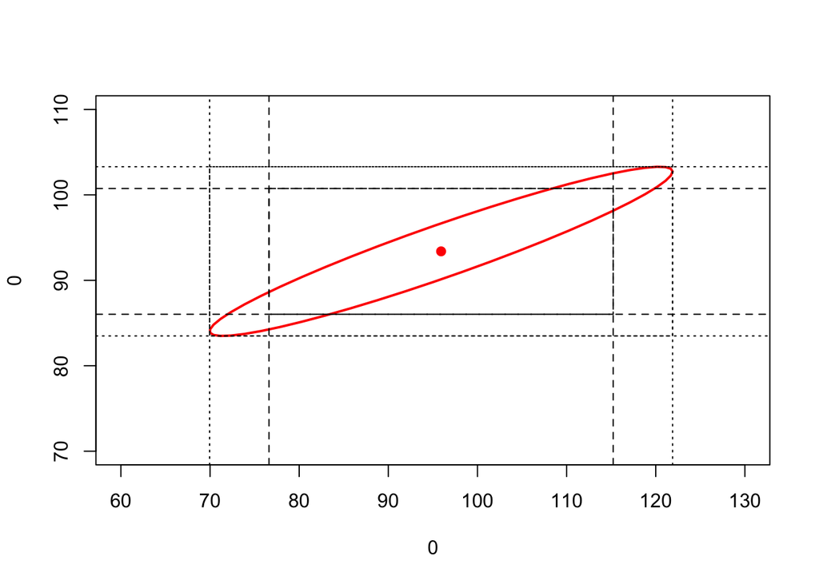

```r
plot(0,0,xlim=c(60,130),ylim=c(70,110))
ellipse(partxbar, as.matrix(partcov), sqrt(qchisq(0.95,p)/n), center.pch=19,         center.cex=1,
        segments=51, add=TRUE, xlab="", ylab="",
        las=par('las'), col=palette()[2], lwd=2, lty=1)
rect(bfci[1,1],bfci[4,1],bfci[1,2],bfci[4,2],lty=2)
rect(ci[1,1],ci[4,1],ci[1,2],ci[4,2],lty=3)
abline(v=ci[1,1],lty=3); abline(v=ci[1,2],lty=3);
abline(h=ci[4,1],lty=3); abline(h=ci[4,2],lty=3);
abline(v=bfci[1,1],lty=2); abline(v=bfci[1,2],lty=2);
abline(h=bfci[4,1],lty=2); abline(h=bfci[4,2],lty=2);
```

#### (e) Obtain the 95% Boferroni confidence interval for “mean head width - mean head length” using $m=6+1=7$ to allow for this statement as well as statements about each individual mean.

위와 같은 상황에서 “mean head width - mean head length”의 Bonferroni confidence interval을 구하면,

$(\bar{x_5}-\bar{x_6}) - z(\frac{\alpha}{2m})\sqrt{\frac{(\bar{x_5}-\bar{x_6})(s_{55}-2s_{56}+s_{66})(\bar{x_5}-\bar{x_6})}{n}}, \bar{x_5}-\bar{x_6}) + z(\frac{\alpha}{2m})\sqrt{\frac{(\bar{x_5}-\bar{x_6})(s_{55}-2s_{56}+s_{66})(\bar{x_5}-\bar{x_6})}{n}},$

이므로, 이를 계산하면,

```r
dif<-xbar[5]-xbar[6];
a<-qnorm(0.05/(2*7))*sqrt(dif^2*(cov[5,5]+cov[6,6]-2*cov[5,6])/n)
bfub<-dif+a ; bflb<-dif-a;
bfci<-cbind(bflb,bfub)
bfci
```

```
##           bflb     bfub
## [1,] -4.737204 -21.5628
```

# 연습문제 5.16

다음으로는 교재에 있는 연습문제 5.16을 풀어보도록 한다.

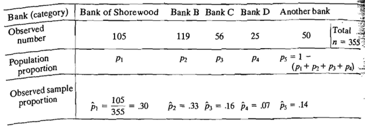

위와 같은 자료이며,

```r
obs<-c(105,119,56,25,50); sp<-c(0.3,0.33,0.16,0.07,0.14);
```

#### (a) Construct simultaneous 95% confidence intervals for $p_1,p_2,...,p_5$.

자료가 355개 있으므로, large sample이라고 생각하고, 비율의 동시신뢰구간을 구하면, 다음과 같이 구할 수 있으므로 이를 계산해보면,

$(p_i-\sqrt{\chi_q^2(\alpha)}\sqrt{\frac{s_{ii}}{n}},p_i+\sqrt{\chi_q^2(\alpha)}\sqrt{\frac{s_{ii}}{n}})$

```r
sigma<-diag(sp)-sp%*%t(sp);
q=4; n=355; p=q+1;
lb<-rep(0,p); ub<-rep(0,p);
for(i in 1:p){
  a<-sqrt(qchisq(0.95,q)*sigma[i,i]/n);
  lb[i]<-sp[i]-a; ub[i]<-sp[i]+a
}
ci<-cbind(lb,ub)
ci
```

```
##              lb        ub
## [1,] 0.22508365 0.3749163
## [2,] 0.25312921 0.4068708
## [3,] 0.10006692 0.2199331
## [4,] 0.02828834 0.1117117
## [5,] 0.08327426 0.1967257
```

#### (b) Construct a simultaneous 95% confidence interval that allows a comparison of the Bank of Shorewood with its major competitor, Bank B. Interpret this interval.

임의의 linear combination에 대해 confidence interval은

$( a'\hat{p} - \sqrt{\chi_q^2(\alpha)}\sqrt{\frac{a'\hat{\Sigma}a}{n}} , a'\hat{p} + \sqrt{\chi_q^2(\alpha)}\sqrt{\frac{a'\hat{\Sigma}a}{n}} )$

두개의 비율을 비교하기 위해, linear combination을 다음과 같이 생각하면,

$a = (1,-1,0,0,0) , a'p = p_1-p_2$

위의 confidence interval은 다음과 같이 계산된다.

$(\hat{p}_1-\hat{p}_2 - \sqrt{\chi_1^2(\alpha)} \sqrt{\frac{s_{11}+s_{22}-2s_{12}}{355}} , \hat{p}_1 - \hat{p}_2 + \sqrt{\chi_1^2(\alpha)}\sqrt{\frac{s_{11}+s_{22}-2s_{12}}{355}} )$

이를 계산해보면,

```r
dif<-sp[1]-sp[2];
a<-sqrt(qchisq(0.95,1)*(sigma[1,1]+sigma[2,2]-2*sigma[1,2])/355);
lb<-dif-a; ub<-dif+a;
ci<-cbind(lb,ub);
ci
```

```
##              lb         ub
## [1,] -0.1125076 0.05250756
```

ci가 0을 포함하고 있는것으로 보아, 둘의 모비율이 거의 비슷하다고 생각할 수 있다.

# 연습문제 5.17

자료는 다음과 같다.

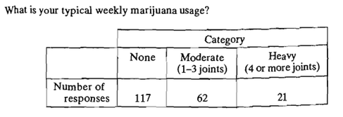

#### Construct 95% simultaneous confidence intervals for the three proportions $p_1, p_2, $ and $p_3 = 1 - (p_1 + p_2)$.

```r
obs<-c(117,62,21); sp<-obs/sum(obs);
```

역시 large sample에서의 비율의 신뢰구간을 구하면 된다. 연습문제 5.16에서와 같은 방법으로 계산하면,

```r
sigma<-diag(sp)-sp%*%t(sp);
q=2; n=sum(obs); p=q+1;
lb<-rep(0,p); ub<-rep(0,p);
for(i in 1:p){
  a<-sqrt(qchisq(0.95,q)*sigma[i,i]/n);
  lb[i]<-sp[i]-a; ub[i]<-sp[i]+a
}
ci<-cbind(lb,ub)
ci
```

```
##              lb        ub
## [1,] 0.49971877 0.6702812
## [2,] 0.22995082 0.3900492
## [3,] 0.05194117 0.1580588
```

# 예제 6.10

```r
n1=271; n2=138; n3=107; n=n1+n2+n3; p=4
x1bar<-c(2.066,0.480,0.082,0.360);
x2bar<-c(2.167,0.596,0.124,0.418);
x3bar<-c(2.273,0.521,0.125,0.383);
S1<-matrix(0,4,4)
S1[lower.tri(S1,diag=TRUE)]<-c(0.291,-0.001,0.002,0.010,0.011,0.000,0.003,0.001,0.000,0.010)
S1<-S1+t(S1)-diag(diag(S1))
S2<-matrix(0,4,4)
S2[lower.tri(S2,diag=TRUE)]<-c(0.561,0.011,0.001,0.037,0.025,0.004,0.007,0.005,0.002,0.019)
S2<-S2+t(S2)-diag(diag(S2))
S3<-matrix(0,4,4)
S3[lower.tri(S3,diag=TRUE)]<-c(0.261,0.030,0.003,0.018,0.017,-0.000,0.006,0.004,0.001,0.013)
S3<-S3+t(S3)-diag(diag(S3))
```

Between matrix와 Within matrix를 구하면

```r
W<-(n1-1)*S1+(n2-1)*S2+(n3-1)*S3;
xbar<-(n1*x1bar+n2*x2bar+n3*x3bar)/n;
B=n1*(x1bar-xbar)%*%t(x1bar-xbar)+n2*(x2bar-xbar)%*%t(x2bar-xbar)+n3*(x3bar-xbar)%*%t(x3bar-xbar);
W;B;
```

```
##         [,1]  [,2]  [,3]  [,4]
## [1,] 183.093 4.417 0.995 9.677
## [2,]   4.417 8.197 0.548 2.405
## [3,]   0.995 0.548 1.379 0.380
## [4,]   9.677 2.405 0.380 6.681
```

```
##           [,1]      [,2]      [,3]      [,4]
## [1,] 3.4687989 1.0985713 0.8106779 0.5859503
## [2,] 1.0985713 1.2306787 0.4500336 0.6157338
## [3,] 0.8106779 0.4500336 0.2317835 0.2311294
## [4,] 0.5859503 0.6157338 0.2311294 0.3085943
```

이렇게 구한다음, 검정을 위해 검정통계량 Wilk’s lambda를 계산하면,

```r
lambda=det(W)/det(B+W);
lambda
```

```
## [1] 0.7627582
```

지금은 Group 3개, variable은 4개인 상황이므로, Wilk’s lambda의 분포는

$(\frac{\Sigma n_l - p - 2}{p})(\frac{1-\sqrt{\Lambda^*}}{\sqrt{\Lambda^*}}) \sim F_{2p,2(\Sigma n_l-p-2)}$

이므로, 좌변에 우리가 구한 Wilk’s lambda를 대입하여 계산하면, 검정통계량은 다음과 같고, F분포의 alpha 분위수는

```r
(n-p-2)*(1-sqrt(lambda))/(p*sqrt(lambda))
```

```
## [1] 18.48786
```

```r
qf(0.99,2*p,2*(n-p-2))
```

```
## [1] 2.528682
```

검정통계량이 $F_{8,1020}(0.01)$을 넘으므로, 가설을 기각할 수 있고 따라서 그룹간의 차이가 있다고 볼 수 있다.

# 예제 6.11

이번에는 같은 자료에 대해서, 4개의 변수중에 하나의 변수 (여기서는 세번째 변수 $X_3$)가 각 그룹마다 차이가 있는지 확인해보려고 한다. 즉, $X_3$(costs of plant operation and maintenance labor)가 private Owner와 nonprofit Owner사이에 차이가 있는지 ($\tau_{13} = \tau_{23}$), 또는 private과 government와 차이가 있는지 등을 알아보려고 한다.

우리는 $\tau_{ki}-\tau_{li}$의 신뢰구간이 다음과 같다는 것을 알고 있다.

$(\bar{x}_{ki}-\bar{x}_{li} - t_{n-g}(\frac{\alpha}{pg(g-1)})\sqrt{\frac{w_{ii}}{n-g}(\frac{1}{n_k}+\frac{1}{n_l})} , \bar{x}_{ki}-\bar{x}_{li} + t_{n-g}(\frac{\alpha}{pg(g-1)})\sqrt{\frac{w_{ii}}{n-g}(\frac{1}{n_k}+\frac{1}{n_l})})$

이것을 이용해 각 신뢰구간을 구해보면,

```r
g=3;
th1=x1bar-xbar; th2=x2bar-xbar; th3=x3bar-xbar;
dif12<-(th1-th2)[3]; dif13<-(th1-th3)[3]; dif23<-(th2-th3)[3];
a12<-qt(0.05/(p*g*(g-1)),n-g,lower.tail=FALSE)*sqrt((1/n1+1/n2)*W[3,3]/(n-g));
a13<-qt(0.05/(p*g*(g-1)),n-g,lower.tail=FALSE)*sqrt((1/n1+1/n3)*W[3,3]/(n-g));
a23<-qt(0.05/(p*g*(g-1)),n-g,lower.tail=FALSE)*sqrt((1/n2+1/n3)*W[3,3]/(n-g));
lb12<-dif12-a12; ub12<-dif12+a12; ci12<-cbind(lb12,ub12);
lb13<-dif13-a13; ub13<-dif13+a13; ci13<-cbind(lb13,ub13);
lb23<-dif23-a23; ub23<-dif23+a23; ci23<-cbind(lb23,ub23);
ci12; ci13; ci23;
```

```
##             lb12        ub12
## [1,] -0.05760551 -0.02639449
```

```
##             lb13        ub13
## [1,] -0.06003765 -0.02596235
```

```
##             lb23       ub23
## [1,] -0.02022171 0.01822171
```